# CRIM 595 Hotspot Project

Kyle Weber

26 June 2023

# PACKAGES

```r
library(tidyverse)
library(leaflet)
library(sf)
library(tigris)
```

## Acquire Data

```r
id.calls <- "1gRoL7lZlwm7sreA5F9WbPoH5su4n4iGS"
calls.temp <- read.csv(sprintf("https://docs.google.com/uc?id=%s&export=download", id.calls))
```

## Wrangle Data

```r
fairfax.roads <- roads("VA", "Fairfax city")
fairfax.city <- county_subdivisions("VA", "Fairfax city")
calls.temp$date <- as.Date(calls.temp$date)
calls.temp$dow <- weekdays(calls.temp$date)
calls.temp$month <- substr(calls.temp$date, 6, 7)
calls.full <- subset(calls.temp, !is.na(calls.temp$lat))

calls.year <- calls.full %>%
  group_by(year) %>%
  summarise(count = n()) %>%
  mutate(PCT = round(count/sum(count)*100,2))

calls.type <- calls.full %>%
  group_by(type) %>%
  summarise(count = n()) %>%
  mutate(PCT = round(count/sum(count)*100,2))

calls.type <- calls.type[order(-calls.type$count),]
diffs <- diff(calls.type$PCT)
diffs <- c(0, diffs)
calls.type$diff <- diffs

calls <- subset(calls.full, calls.full$type == 'TRESPASSING')
```

## Visualize Data

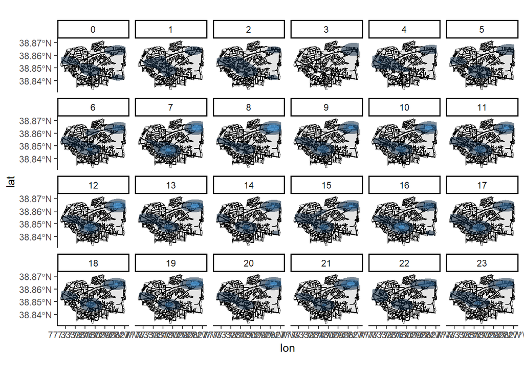

```r
ggplot() +
  geom_sf(data = fairfax.city) +
  geom_sf(data = fairfax.roads) +
  stat_density2d(aes(x = lon, y = lat, fill = ..level.., alpha = 0.01),
                 size = 0.001, bins = 4, data = calls, geom = "polygon") +
  theme_classic() +
  theme(legend.position = "none") +
  facet_wrap(~ hour, nrow = 4)
```

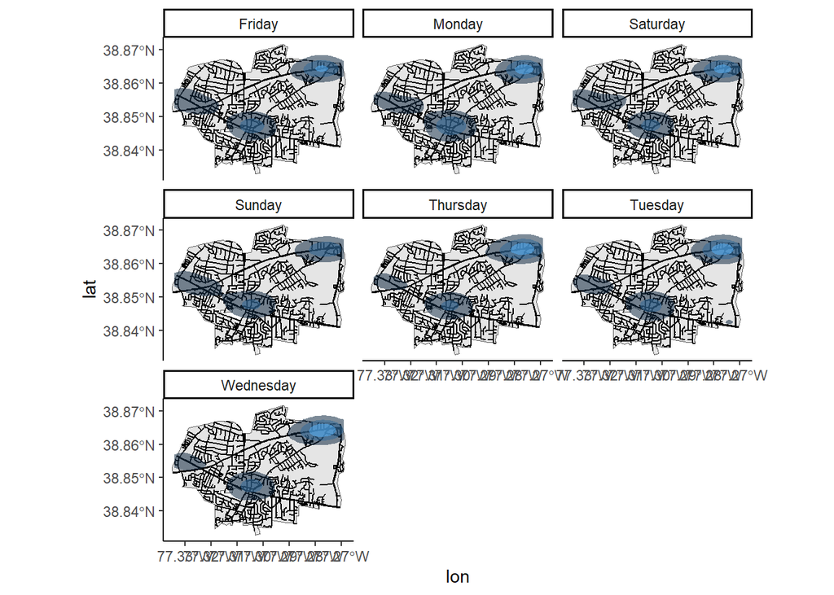

```r
ggplot() +
  geom_sf(data = fairfax.city) +
  geom_sf(data = fairfax.roads) +
  stat_density2d(aes(x = lon, y = lat, fill = ..level.., alpha = 0.01),
                 size = 0.001, bins = 4, data = calls, geom = "polygon") +
  theme_classic() +
  theme(legend.position = "none") +
  facet_wrap(~ dow, nrow = 3)
```

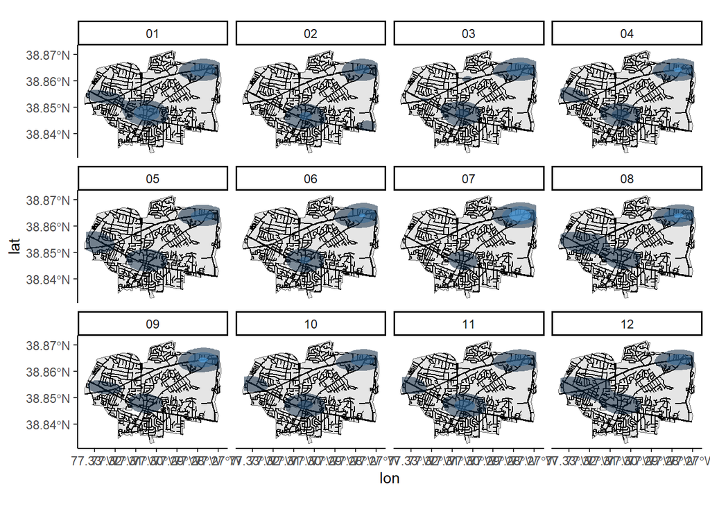

```r
ggplot() +
  geom_sf(data = fairfax.city) +
  geom_sf(data = fairfax.roads) +
  stat_density2d(aes(x = lon, y = lat, fill = ..level.., alpha = 0.01),
                 size = 0.001, bins = 4, data = calls, geom = "polygon") +
  theme_classic() +
  theme(legend.position = "none") +
  facet_wrap(~ month, nrow = 3)
```

```r
leaflet(calls) %>%
  addProviderTiles("CartoDB.DarkMatter") %>%
  addMarkers(lng = ~lon, lat = ~lat,
             popup = paste(
               "Call Type: Trespassing", calls$type, "<br>",
               "Date:", calls$date),
             clusterOptions = markerClusterOptions()) %>%
  addPolygons(data = fairfax.city)
```

[interactive chart not shown]

# ANALYTICS

## Current Hotspots

For trespassing calls for service there were two clear hot-spots: the heart of downtown on the intersection of University Dr and Main St and the shopping center in Northeast at the intersection of Blenheim Blvd and Fairfax Blvd. There were hot-spots at the shopping center on Monday-Saturdays, From 7am-9PM with a two hour lapse around 4-5pm and on April, June, July, August and September. For the downtown area there was only hot-spots at 7am and 4pm. The shopping center provides various forms of entertainment like shopping, eating, and bars. Downtown has drinking and eating places, but is less concentrated than in the Northeast. It makes sense that during the summer months and in April there is the most activity because that is when most people are out of school, on spring break, or take the most vacation so having an uptick in trespassing makes sense. Same with the clear hot-spots during times where most people will be awake from 7am-9pm.

## Current Coldspots

No matter what time of the day, day of the week or month of the year there were four clear cold-spots. In the northern area of the city between Fairfax blvd and route 66, the central eastern area, the southern area below Main St, and the northwest. The northern, northwest and south are all residential areas and the central east area is home to the Army Navy Country Club. These area will seldom see call for service for trespassing due to the lack of concentrated foot traffic in the areas.

## Future Analysis

In the future I expect all four cold-spots to maintain a lack of trespassing calls for service unless there is a shift in the districting in the city to encompass either more nightlife or more commercial businesses in the area. In regards to the hot-spots I would expect that the northeast to continue being a major hot-spot with gaps being filled in the month of May, from the hours of 4-5pm and on Sundays to match the consistency. I would also expect the number of hot-spots in the downtown area to continue to rise in similar months and hours to the northeast. Looking at the clusters the number of calls for service downtown is similar to the number in northeast so if in the long run the number of hot-spots becomes closer to that of the northeast it would not be surprising.